# STAT5003 Project Final Stage

GROUP 22

10/7/2021

- 510317173 Xumou Zhang
- 510138903 Yichen Chen
- 500342776 Xiaotong Yu
- 500704309 Max Byrnes
- 510089546 Zhuoxi Kuang
- 460298672 Rishik Bhandary

### 1. Overview of the Problem:

Soccer is the most popular sport in the world and is played between two sides of 11 players. Each player plays in a certain position, each with its own functionality. Consequently, players in different positions have different compositions in terms of their speed, shot accuracy, passing and so on. For managers and scouts of teams from high to low levels of play, it is therefore incredibly useful to create a model to help identify the best positions for future players to play in, allowing for optimised training and team compositions.

From this scenario and the availability of detailed soccer player data, our research question is: "given attributes related to the appraisal of different players regarding technical skill, physical build and their valuations (whether monetary or reputation), can their position be accurately predicted?

### 2. Dataset description:

#### 2.1 Basic description

The dataset we choose is the “FIFA 19 complete player dataset” downloaded from kaggle. The size of the dataset is 8.93MB and contains 18207 observations of players (rows) with 89 features (columns). 71 of these columns are numerical while 18 are categorical. These features include information such as player height, wage, short passing ability, free kick accuracy, sprint speed, international reputation and crossing. Most features representing technical skills are values between 0 and 100 (apart from weak foot skill between 1 and 5), while heights and weights were in imperial units and wages and values were in Euros. owing to too many features and page constraint, only a few rows are shown below.

```r
dat = read.csv('data.csv', encoding = "UTF-8")
dim(dat)
```

```
## [1] 18207    89
```

```r
#head(dat,2)[c(3,4, 6,8:10,12:15)]
#head(dat,2)
```

The label for this dataset was chosen to be player positions, originally with 27 classes such as left wing (LW) and right forward (RF), which were later relabelled as either forwards (F), midfielders (M), defenders (D) or goalkeepers (G) as players perform just as well in similar positions to what they usually play. For example, a right midfielder would also be suitable to play as a centre-midfielder (both midfield roles), as opposed to a striker or a goalkeeper.

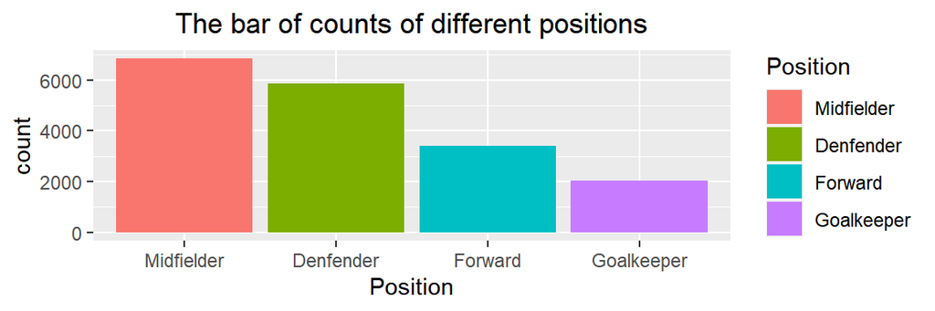

```r
dat$Position = recode_factor(dat$Position, CAM = 'Midfielder', CB = 'Denfender', CDM = 'Midfielder', CF = 'Forward', GK = 'Goalkeeper', LAM = 'Midfielder', CM = 'Midfielder', LB = 'Denfender',
                                          LCB = 'Denfender', LCM = 'Midfielder', LDM = 'Midfielder', LF = 'Forward', LM = 'Midfielder', LS = 'Forward', LW = 'Forward', LWB = 'Denfender',
                                          RAM = 'Midfielder', RB = 'Denfender', RCB = 'Denfender', RCM = 'Midfielder', RDM = 'Midfielder', RF = 'Forward', RM = 'Midfielder', RS = 'Forward',
                                          RW = 'Forward', RWB = 'Denfender', ST = 'Forward')
dat = dat[-which(dat$Position==''),]
dat$Position = droplevels(dat$Position)
ggplot(dat, aes(x=Position,fill=Position)) + geom_bar(stat="count") + ggtitle("The bar of counts of different positions")+theme(plot.title = element_text(hjust = 0.5))
```

It can be seen from the above barcharts that the position classes is only somewhat balanced, with the most frequent class (midfield) having almost 7000 observations and the least frequent (goalkeepers) having around 2000.

#### 2.2 Difficulties

It is difficult to deal with this dataset because of several reasons. One is that it has a really high dimension count of 89. We will need to reduce the dimension count before the model implementation in phase 2 of our project. Another reason is that the dataset has a mix of data types. We will need to identify each of them and transform them into the data we are capable to use during the classification model implementation.

### 3. Data cleaning

After conversion of features and before the deletion of columns, there were found to be 1504 rows with missing values (8.3%) with the largest amount of missing data associated with the release clause features (1504), this is because a small amount of players do not play for clubs and their conversion from characters to numeric data resulted in NA values.

#### 3.1 Format Transforming and deleting irrelevant columns

```r
# converting to numeric values and factor
dat$Preferred.Foot = as.factor(dat$Preferred.Foot) # setting as factor rather than strings
dat$Work.Rate = as.factor(dat$Work.Rate) # setting as factor rather than strings
dat$Height = as.numeric(substr(dat$Height,1,1))*30.48+as.numeric(substr(dat$Height,3,4))*2.54 # feet and inches -> cm
dat$Weight = as.numeric(substr(dat$Weight,1,3))/2.2
dat$Value = ifelse(substr(dat$Value, nchar(dat$Value), nchar(dat$Value))=='M', as.numeric(substr(dat$Value,2,nchar(dat$Value)-1))*1000,as.numeric(substr(dat$Value,2,nchar(dat$Value)-1))) # thousands of dollars
dat$Wage = as.numeric(substr(dat$Wage,2,nchar(dat$Wage)-1)) # thousands
dat$Release.Clause = as.numeric(substr(dat$Release.Clause,2,nchar(dat$Release.Clause)-1)) # millions of dollars
dat$Body.Type = as.factor(dat$Body.Type)

# deleting some irrelevant columns
dat = dat[,-c(1:3,5:7,10:11,21,23:26,29:54,84:88)]
```

#### 3.2 Outliers

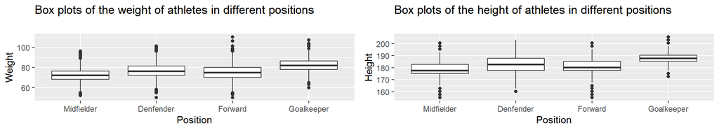

As shown in the box plots each position’s height and weight above. It can be seen that each positions has outliers with forwards having the most for both weight and height. For height, it can be seen that defense only has one outlier while the average heights and weights are the largest for goalkeepers.

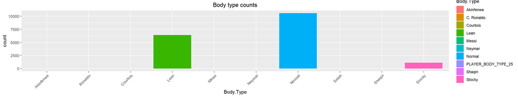

```r
short.body.type = c('Akinfenwa','Ronaldo','Courtois','Lean','Messi','Neymar','Normal','Salah','Shaqiri','Stocky')
ggplot(dat, aes(x=Body.Type,fill=Body.Type)) + geom_bar(stat="count") + theme(axis.text.x = element_text(angle = 45,hjust=1)) + scale_x_discrete(labels=short.body.type) + ggtitle("Body type counts")+theme(plot.title = element_text(hjust = 0.5))
```

The plot of body types reveal 7 outliers with only 1 value (body types of specific players) which are to be imputed to one of the most frequent classes (Lean, Normal or Stocky) according to calculate their BMI as part of preprocessing.

#### 3.3 Missing values

```r
re <- c(sum(complete.cases(dat)),sum(!complete.cases(dat)),mean(!complete.cases(dat)))
re
```

```
## [1] 1.664300e+04 1.504000e+03 8.287871e-02
```

- The number of rows without missing values is 16643.
- The number of rows with missing values is 1504.
- The proportion containing missing values is 8.3%.

#### 3.4 imputating missing values and fixing outliers

```r
wage.na.index = which(is.na(dat$Wage))
value.na.index = which(is.na(dat$Value))
rc.na.index = which(is.na(dat$Release.Clause))

lin.reg.wage = lm(Wage ~ Overall ,data=na.omit(dat))
complete.wage = dat[-wage.na.index,]
missing.wage = dat[wage.na.index,]
wage.pred = predict(lin.reg.wage, newdata=(missing.wage[,-5]))

lin.reg.value = lm(Value ~Overall,data=na.omit(dat))
complete.value = dat[-value.na.index,]
missing.value = dat[value.na.index,]
value.pred = predict(lin.reg.value, newdata=(missing.value[,-4]))

lin.reg.rc = lm(Release.Clause ~Overall + Potential,data=na.omit(dat))
complete.rc = dat[-rc.na.index,]
missing.rc = dat[rc.na.index,]
rc.pred = predict(lin.reg.rc, newdata=(missing.rc[,-45]))

dat[wage.na.index,5] = wage.pred
dat[value.na.index,4] = value.pred
dat[rc.na.index,45] = rc.pred
dat = dat[dat$Wage > 0 & dat$Value > 0 & dat$Release.Clause > 0,]

dat$Body.Type[dat$Body.Type %in% c('Stocky','Normal','Lean')==F]=NA
mlog.bt = nnet::multinom(Body.Type ~ Weight/(Height^2),data=na.omit(dat))
bt.na.index = which(dat$Body.Type %in% c('Normal','Lean','Stocky')==F)
complete.bt = dat[-bt.na.index,]
missing.bt = dat[bt.na.index,]
bt.pred = predict(mlog.bt, newdata=(missing.bt[,-12]))
dat$Body.Type[bt.na.index] = bt.pred
dat$Body.Type = droplevels(dat$Body.Type)
dat$Work.Rate = droplevels(dat$Work.Rate)
dat$Preferred.Foot = droplevels(dat$Preferred.Foot)
```

### 3.4.Initial data analysis

#### 3.4.1 Histogram and Density

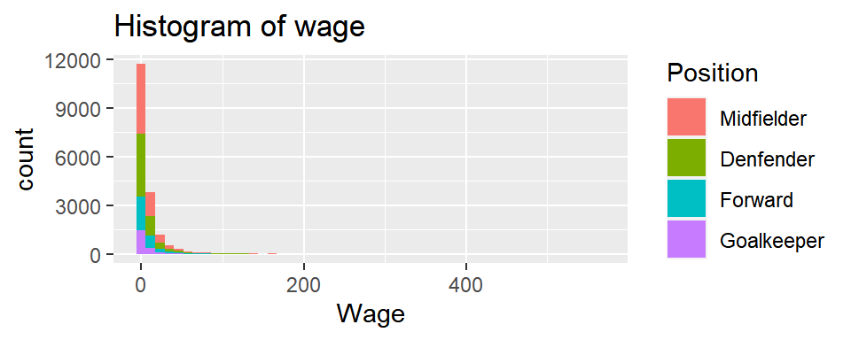

```r
ggplot(dat, aes(x=Wage,fill=Position)) + geom_histogram(bins=50) + ggtitle("Histogram of wage")
```

Wage are Right skewed (most of the data are on the lower(left) side of the distributed)

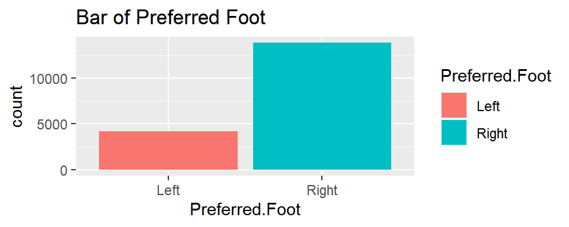

```r
ggplot(dat, aes(x=Preferred.Foot,fill=Preferred.Foot)) + geom_bar() + ggtitle("Bar of Preferred Foot")
```

Most of the players are Right Footed.

```r
#shows different distributions for positions for acceleration - this justifies our recoding into positions I think
p1 = ggplot(dat, aes(x = Acceleration,group=Position,col=Position)) + geom_histogram(aes(y=..density..),fill='white',binwidth = 2, size=0.5)+ geom_density(alpha=0.85, size=1,bw=4) +ggtitle('Acceleration histogram and density (bw=4)')+ theme(plot.title = element_text(size=9))+geom_vline(xintercept = mean(dat$Acceleration), color="blue")+theme(legend.key.size = unit(2.5, 'mm'))

p2 = ggplot(dat, aes(x = Penalties,group=Position,col=Position)) + geom_histogram(aes(y=..density..),fill='white',binwidth = 2, size=0.5)+ geom_density(alpha=0.85, size=1,bw=4) + ggtitle('Penalty skill histogram and density (bw=4)')+ theme(plot.title = element_text(size=9)) + geom_vline(xintercept = mean(dat$Penalties), color="blue")+theme(legend.key.size = unit(2.5, 'mm'))
p3 = ggplot(dat, aes(x = StandingTackle,group=Position,col=Position)) + geom_histogram(aes(y=..density..),fill='white',binwidth = 2, size=0.5)+ geom_density(alpha=0.85, size=1,bw=4) + ggtitle('Standing tackle histogram and density (bw=4)')+ theme(plot.title = element_text(size=9)) + geom_vline(xintercept = mean(dat$StandingTackle), color="blue")+theme(legend.key.size = unit(2.5, 'mm'))
p4 = ggplot(dat, aes(x = Reactions,group=Position,col=Position)) + geom_histogram(aes(y=..density..),fill='white',binwidth = 2, size=0.5)+ geom_density(alpha=0.85, size=1,bw=4) + ggtitle('Reactions histogram and density (bw=4)')+ theme(plot.title = element_text(size=9)) + geom_vline(xintercept = mean(dat$Reactions), color="blue")+theme(legend.key.size = unit(2.5, 'mm'))
```

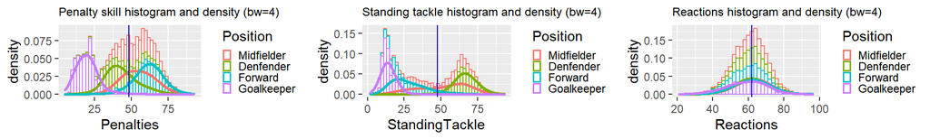

```r
gridExtra::grid.arrange(p2,p3, p4, ncol=3)
```

#### 3.4.2 Correlation Matrix

- The below correlation matrix depicts the dataset’s feature correlations. Most of the attributes denoting players’ technical skills are correlated with their positions and other technical skills which is expected as players require a specific skill set suited to their position. Defenders prevent scoring opportunities and thus need to be good at intercepting, marking, and tackling, the correlation between these variables is at least 0.9. Forwards find situations to make accurate shots on target. There are subsequent high positive correlations between these types of skills like penalties and finishing (0.82). The differences between the skills typical of these positions are highlighted in the lack of correlation such as penalties and marking (0.04).
- Midfielders are more focused on the movement of the ball between forwards and defense. They tend to be more well-rounded which is seen in long-passing being relatively correlated with all other skills. While similar skills such as dribbling, and ball control have high correlations (0.9). If goalkeeper-specific skill sets were included in the analysis, there would likely be a significant negative correlation with the other skills as goalkeeping is the most unique position with no need for outfield skills.

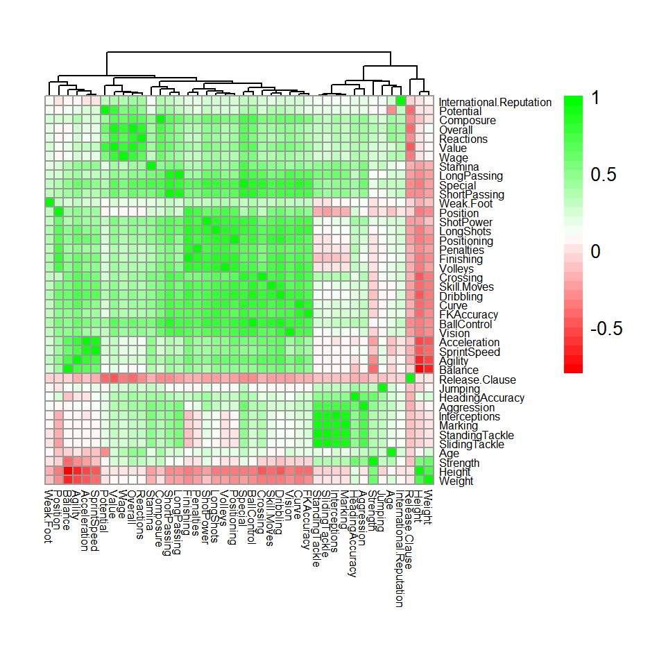

```r
new.dat = dat
new.dat <- na.omit(new.dat)

#as.character(new.dat$Position)
new.dat$Position=ifelse(new.dat$Position == "Goalkeeper",0,ifelse(new.dat$Position =="Denfender",1,ifelse(new.dat$Position == "Midfielder",2,3)))
new.dat <- subset(new.dat, select = -c(Work.Rate, Body.Type, Preferred.Foot ) )
#correlation matrix

cc = cor(new.dat, method='spearman')
palette = colorRampPalette(c("red", "white", "green")) (30)
pheatmap(mat = cc,
         col = palette,
         treeheight_row = 0,
         treeheight_col = 20,
         fontsize_row = 6,
         fontsize_col = 6,
         cellheight = 5,
         cellwidth = 5,
         clustering_distance_rows = 'correlation',
         display_numbers = F,
         number_format = '%.2f')
```

### 4. Feature Engineering:

#### 4.1 One-hot Encoding

- We implement the one-hot encoding for the categorical features in our dataset.The main purpose of one-hot encoding is to transfer categorical data into numerical data for the system to understand. And since there is no ranking between different categories, we cannot using simple integers to represent it, therefore we are using one-hot encoding.

```r
dat2 <- cbind.data.frame(select_if(dat,is.numeric),as.data.frame(model.matrix(~Body.Type + Work.Rate + Preferred.Foot -1,dat)))
```

#### 4.2 PCA

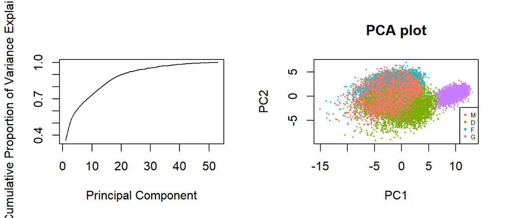

```r
pca = prcomp(dat2,scale=T,center=T)
cum.var = cumsum(pca$sdev^2/sum(pca$sdev^2))

par(mfrow=c(1,2))
plot(1:length(cum.var),cum.var, xlab = "Principal Component", ylab = "Cumulative Proportion of Variance Explained", type="l")
colmap= c('#F8766D','#7CAE00','#00BFC4','#C77CFF')
dev.size=c(1,1)

plot(pca$x[,1],pca$x[,2],col=colmap[as.numeric(dat$Position)],pch=16,cex=0.3,xlab='PC1',ylab='PC2', main = "PCA plot")
legend('bottomright',legend=c('M','D','F','G'),col=colmap,pch=16,cex=0.5)
```

```r
#final data
dat.pca <- cbind.data.frame(pca$x[,1:which.max(cum.var>0.95)], Position = dat$Position)
dat.pca <- as.data.frame(dat.pca)
```

### 5. Classifiction algorithms

The four classification algorithms we want to implement in this project are: * KNN * Logistic * SVM * Random Forest

#### 5.1 Split the dataset

```r
set.seed(2)
inTrain <- createDataPartition(dat.pca$Position, p = .75)[[1]]
train <- dat.pca[ inTrain, ]
test  <- dat.pca[-inTrain, ]
```

#### 5.2.1 KNN

- For the knn model, classification is done by determining the classes based on other data points in a neighbourhood around each test data point.
- In this scenario, the parameters tuned where the numbers of nearest-neighbours. Due to the knn algorithm working of a majority voting system, The choices were all odd numbers between (and including) 5 and 25.

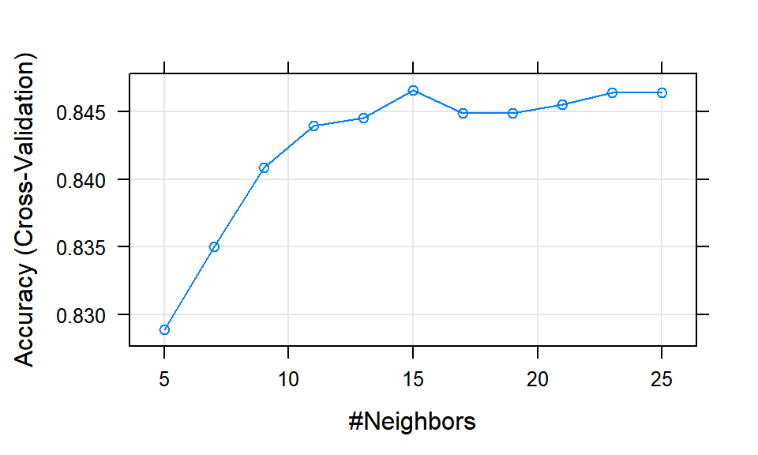

```r
set.seed(1234)
knn.fitcontrol <- trainControl(method = "cv",
                               number = 5,
                               classProbs = TRUE)


knn.grid <- expand.grid(.k = seq(5, 25, by = 2))

set.seed(1234)
knn.model = train(Position~.,
                  data = train,
                  method = "knn",
                  trControl = knn.fitcontrol,
                  metric = 'Accuracy',
                  tuneGrid = knn.grid)

#print(knn.model)
plot(knn.model)
```

```r
knn.pred <- predict(knn.model, newdata = test)
```

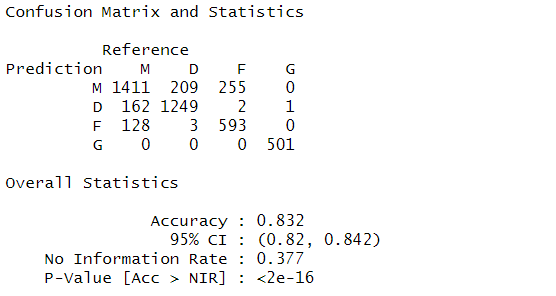

#### 5.2.2 Logistic Regression

- For the logistic regression model, predictions are done by transforming a regression equation, bounding it between 0 and 1 to return probabilities of a data point being in a class.
- The hyperparameters to be tuned were the type of regularisation (lasso = 1, ridge = 0), or in other words, the penalty for model overspecification, and lambda, the strength of the regularisation penalty.

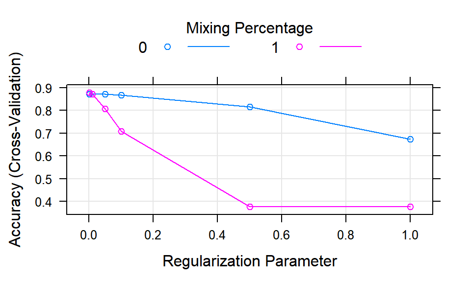

```r
set.seed(1234)
lrcontrol <- trainControl(method = "cv", number = 5)


lr.grid <- expand.grid(alpha = c(0,1),
                       lambda = c(0.001,0.01,0.05,0.1,0.5,1))

set.seed(1234)
lr.model <- train(Position~., train, method = "glmnet",
             metric = "Accuracy",
             tuneGrid = lr.grid,
             trControl = lrcontrol)

#print(lr.model)
plot(lr.model)
```

```r
lr.pred <- predict(lr.model, newdata = test)
```

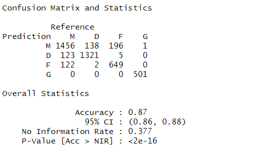

#### 5.2.3 SVM

*The main idea of SVM model is to find the plane that separates the classes in the feature space to achieve classification.* In the SVM model, we mainly focus on tuning the sigma and C parameters. * Here, sigma controls the curvature of the decision boundary and C is the cost (regularisation term in Lagrange formulation). * The hyperparameter choices searched in the random search were 0.0007,0.0008 & 0.0009 for sigma and 0.13, 0.15 & 0.17 for C.

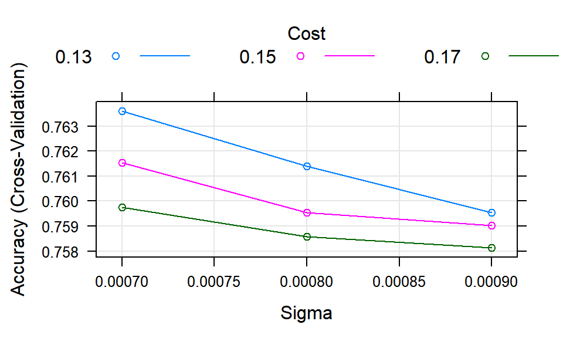

```r
set.seed(1234)
svm.fitcontrol <- trainControl(method = "cv",
                               number = 5,
                               classProbs = TRUE)

svm.grid <- expand.grid(expand.grid(sigma=c(0.0007,0.0008,0.0009),
                                    C=c(0.13,0.15,0.17)))

set.seed(1234)
svm.model = train(Position~.,
                  data = train,
                  method = 'svmRadial',
                  trControl = svm.fitcontrol,
                  metric = 'Accuracy',
                  tuneGrid = svm.grid)
#print(svm.model)
plot(svm.model)
```

```r
svm.pred <- predict(svm.model, newdata = test)
```

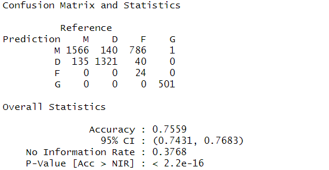

- From the figure, it can be seen that the 5-fold cross-validation accuracy reaches its peak value when sigma=0.0007, c=0.13 (around 0.764). Therefore, these two values were used in predicting the test set. From the confusion matrix, goalkeepers were predicted very accurately, while a significant majority of the forwards were misclassed as midfielders.
- The accuracy score was 0.756 while the macro F1-score was 0.670.

#### 5.2.4 Random Forest

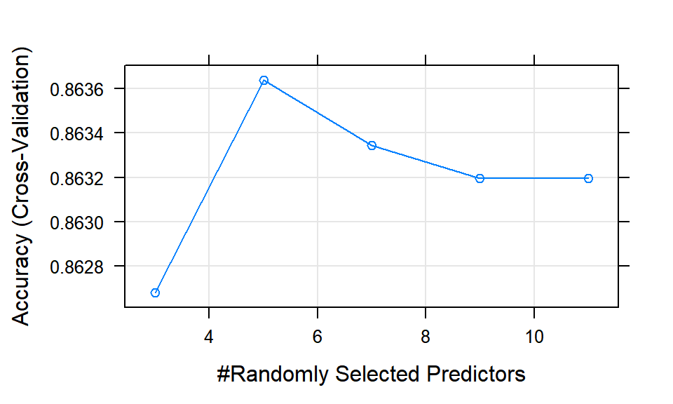

```r
set.seed(1234)
rf.control <- trainControl(method = "cv", number = 5)
rf.grid <- expand.grid(mtry=c(3,5,7,9,11))

set.seed(1234)
rf.model <- train(Position~., train,
                 method = "rf",
                 metric = "Accuracy",
                 tuneGrid = rf.grid,
                 trControl = rf.control)
#print(rf.model)
plot(rf.model)
```

```r
rf.pred <- predict(rf.model, newdata = test)
```

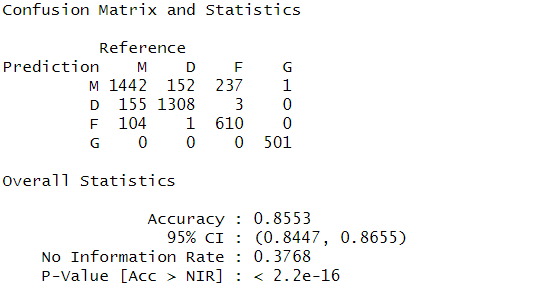

### 6 Classification Models Performance Evaluation and Comparison

#### 6.1 Learning curve

A learning curve shows the validation and training score of an estimator for varying numbers of training samples. It is a tool to find out how much we benefit from adding more training data and whether the estimator suffers from a variance error or a bias error.

```r
set.seed(1234)
inTrain_a <- createDataPartition(dat.pca$Position, p = .01)[[1]]
inTrain_b <- createDataPartition(dat.pca$Position, p = .15)[[1]]
inTrain_c <- createDataPartition(dat.pca$Position, p = .25)[[1]]
inTrain_d <- createDataPartition(dat.pca$Position, p = .60)[[1]]
inTrain_e <- createDataPartition(dat.pca$Position, p = .75)[[1]]

train_a <- dat.pca[ inTrain_a, ]
train_b <- dat.pca[ inTrain_b, ]
train_c <- dat.pca[ inTrain_c, ]
train_d <- dat.pca[ inTrain_d, ]
train_e <- dat.pca[ inTrain_e, ]


list_train = list(train_a,train_b,train_c,train_d,train_e)
```

#### 6.1.1 Logistic Regression

```r
set.seed(1234)
lrcontrol <- trainControl(method = "cv", number = 3)

lr.grid <- expand.grid(alpha = c(1),
                       lambda = c(0.001))

set.seed(1234)
lr_result = lapply(list_train, function(x) {
  lr.model = train(Position~., x, method = "glmnet",
             metric = "Accuracy",
             tuneGrid = lr.grid,
             trControl = lrcontrol)
  lr.train.pred = predict(lr.model, newdata = x)
  c(confusionMatrix(lr.train.pred,x$Position)$overall[1], mean(lr.model$resample$Accuracy), nrow(x))
})
```

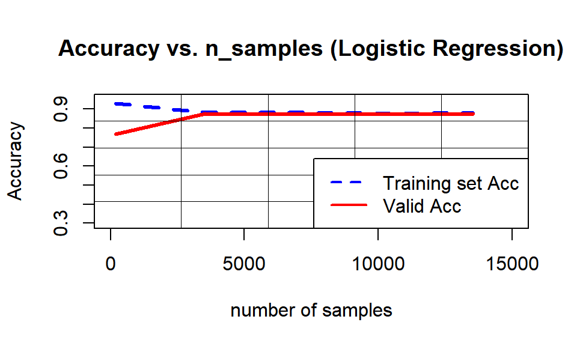

```r
lr_train = as.vector(unlist(lapply(lr_result, function(x) x[1])))
lr_valid = as.vector(unlist(lapply(lr_result, function(x) x[2])))
lr_nrow = as.vector(unlist(lapply(lr_result, function(x) x[3])))
line_train = data.frame(lr_nrow,lr_train)

sp1_lr=spline(lr_nrow,lr_train,n=5)
sp2_lr=spline(lr_nrow,lr_valid,n=5)

plot(sp1_lr, xlim = c(0, 15000),ylim = c(0.3,0.95), xlab = "number of samples", ylab = "Accuracy",
     type = "l",col = "blue", lwd = 3, main = "Accuracy vs. n_samples (Logistic Regression)",lty = 2
     )
lines(sp2_lr, col = "red", lwd = 3,lty = 1
     )

grid(5,5, lwd = 0.5,lty = 1, col = "black")
legend("bottomright", c("Training set Acc", "Valid Acc"), col = c("blue","red"), lty = c(2,1),lwd = 2)
```

The learning curve of logistic regression is the best one, for it has both validation score and training score converging to a high value, which means not underfitting. What’s more, they are close enough for us to conclude that the model is also not overfitting. It can be said that this time logistic regression is the most robust and accurate model

#### 6.1.2 KNN

```r
set.seed(1234)
knncontrol <- trainControl(method = "cv", number = 3)

knn.grid <- expand.grid(k = c(15))

set.seed(1234)
a = lapply(list_train, function(x) {
  knn.model = train(Position~.,
                    data = x,
                    method = "knn",
                    trControl = knn.fitcontrol,
                    metric = 'Accuracy',
                    tuneGrid = knn.grid)
  knn.train.pred = predict(knn.model, newdata = x)
  c(confusionMatrix(knn.train.pred,x$Position)$overall[1], mean(knn.model$resample$Accuracy), nrow(x))
})
```

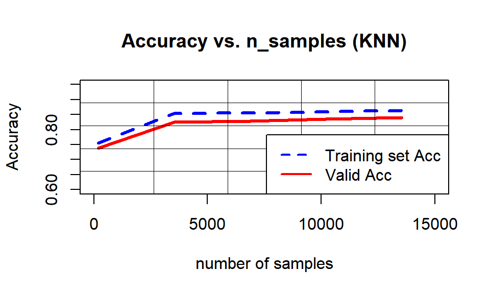

```r
knn_train = as.vector(unlist(lapply(a, function(x) x[1])))
knn_valid = as.vector(unlist(lapply(a, function(x) x[2])))
knn_nrow = as.vector(unlist(lapply(a, function(x) x[3])))
line_train = data.frame(knn_nrow,knn_train)

sp1_knn=spline(knn_nrow,knn_train,n=5)
sp2_knn=spline(knn_nrow,knn_valid,n=5)

plot(sp1_knn, xlim = c(0, 15000),ylim = c(0.6,0.95), xlab = "number of samples", ylab = "Accuracy",
     type = "l",col = "blue", lwd = 3, main = "Accuracy vs. n_samples (KNN)",lty = 2
     )
lines(sp2_knn, col = "red", lwd = 3,lty = 1
     )

grid(5,5, lwd = 0.5,lty = 1,col = "black")
legend("bottomright", c("Training set Acc", "Valid Acc"), col = c("blue","red"), lty = c(2,1), lwd = 2)
```

For the learning curve of the KNN plot depicted in the figure, it can be seen that both the accuracy on the training set and validation set increased when the number of samples increased while the differences between the curves were kept relatively constant. Implying a lack of overfitting or underfitting.

#### 6.1.3 SVM

```r
set.seed(1234)
SVMcontrol <- trainControl(method = "cv", number = 3)

SVM.grid <- expand.grid(sigma = c(8e-04),
                       C = c(0.15))

set.seed(1234)
SVM_result = lapply(list_train, function(x) {
  SVM.model = train(Position~., x, method = "svmRadial",
             metric = "Accuracy",
             tuneGrid = SVM.grid,
             trControl = SVMcontrol)
  SVM.train.pred = predict(SVM.model, newdata = x)
  c(confusionMatrix(SVM.train.pred,x$Position)$overall[1], mean(SVM.model$resample$Accuracy), nrow(x))
})
```

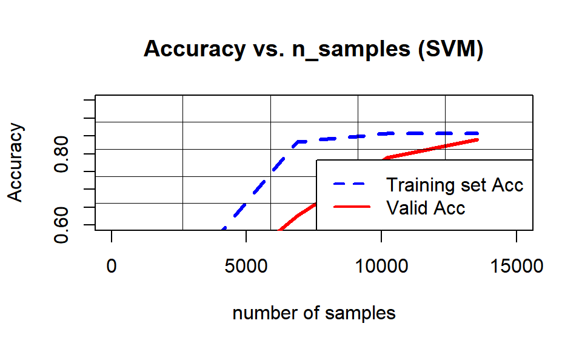

```r
SVM_train = as.vector(unlist(lapply(SVM_result, function(x) x[1])))
SVM_valid = as.vector(unlist(lapply(SVM_result, function(x) x[2])))
SVM_nrow = as.vector(unlist(lapply(SVM_result, function(x) x[3])))
line_train = data.frame(SVM_nrow,SVM_train)

sp1_SVM=spline(SVM_nrow,SVM_train,n=5)
sp2_SVM=spline(SVM_nrow,SVM_valid,n=5)

plot(sp1_SVM, xlim = c(0, 15000),ylim = c(0.6,0.95), xlab = "number of samples", ylab = "Accuracy",
     type = "l",col = "blue", lwd = 3, main = "Accuracy vs. n_samples (SVM)",lty = 2
     )
lines(sp2_SVM, col = "red", lwd = 3,lty = 1
     )

grid(5,5, lwd = 0.5,lty = 1, col = "black")
legend("bottomright", c("Training set Acc", "Valid Acc"), col = c("blue","red"), lty = c(2,1),lwd = 2)
```

The accuracy of SVM is much lower than that of other models such as LR and KNN, which might be the evidence of underfitting. However, because the learning curve of SVM does not converge, we cannot simply conclude that it is caused by overfitting or underfitting. According to the learning curve, the reason for the low accuracy might be that the SVM model needs more training samples. In fact, we can see from the trend of the curve that if we continue to increase the number of samples, the accuracy of SVM is likely to be higher.

#### 6.1.4 Random Forest

```r
set.seed(1234)
rf.fitcontrol <- trainControl(method = "cv", number = 3)

rf.grid <- expand.grid(mtry=c(5))

set.seed(1234)
rf.result = lapply(list_train, function(x) {
  rf.model <- train(Position~., train,
                   method = "rf",
                   metric = "Accuracy",
                   tuneGrid = rf.grid,
                   trControl = rf.control)
  rf.train.pred = predict(rf.model, newdata = x)
  c(confusionMatrix(rf.train.pred,x$Position)$overall[1], mean(rf.model$resample$Accuracy), nrow(x))
})
```

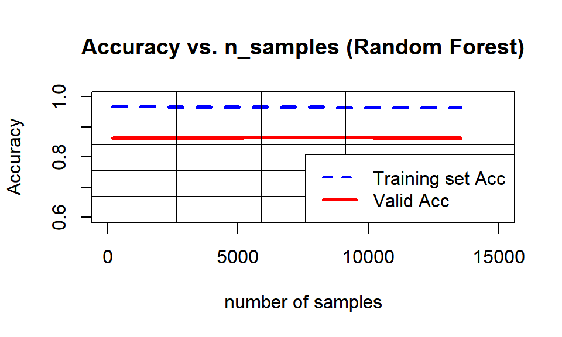

```r
rf_train = as.vector(unlist(lapply(rf.result, function(x) x[1])))
rf_valid = as.vector(unlist(lapply(rf.result, function(x) x[2])))
rf_nrow = as.vector(unlist(lapply(rf.result, function(x) x[3])))
line_train = data.frame(rf_nrow,rf_train)

sp1_rf=spline(rf_nrow,rf_train,n=5)
sp2_rf=spline(rf_nrow,rf_valid,n=5)

plot(sp1_rf, xlim = c(0, 15000),ylim = c(0.6,1), xlab = "number of samples", ylab = "Accuracy",
     type = "l",col = "blue", lwd = 3, main = "Accuracy vs. n_samples (Random Forest)",lty = 2
     )
lines(sp2_rf, col = "red", lwd = 3,lty = 1
     )

grid(5,5, lwd = 0.5,lty = 1,col = "black")
legend("bottomright", c("Training set Acc", "Valid Acc"), col = c("blue","red"), lty = c(2,1), lwd = 2)
```

#### 6.2 Classifiers Comparison

```r
runningtime<- function(model){
  st<- Sys.time()
  pred<- predict(model, newdata=test)
  et<- Sys.time()
  rt<-as.numeric(et-st)
}
#knn
knn.time<- runningtime(knn.model)
knn.cm<-confusionMatrix(knn.pred,test$Position)
knn.acc<-knn.cm$overall[["Accuracy"]]
knn.f1<- mean(knn.cm$byClass[,7])
#logstic regression
lr.time<-runningtime(lr.model)
lr.cm<-confusionMatrix(lr.pred,test$Position)
lr.acc<-lr.cm$overall[["Accuracy"]]
lr.f1<- mean(lr.cm$byClass[,7])
#svm
svm.time<- as.numeric(runningtime(svm.model))
svm.cm<-confusionMatrix(svm.pred,test$Position)
svm.acc<-svm.cm$overall[["Accuracy"]]
svm.f1<- mean(svm.cm$byClass[,7])
#random forest
rf.time <- runningtime(rf.model)
rf.cm<-confusionMatrix(rf.pred,test$Position)
rf.acc<-rf.cm$overall[["Accuracy"]]
rf.f1<- mean(rf.cm$byClass[,7])
```

```r
classifier<- c("KNN", "Logistic Regression","SVM", "Random Forest")
parameters<- c("k=15", "alpha=1, lambda=0.001","sigma=7e-04, c=0.13","mtry=5, ntrees=1000")
accuracy<- c(knn.acc, lr.acc , svm.acc, rf.acc)
f1score<- c(knn.f1, lr.f1, svm.f1, rf.f1)
time<- c(knn.time, lr.time, svm.time, rf.time)
options(digits=2)
compare.df<- data.frame(Classifier=classifier,Parameters=parameters,Accuracy=accuracy,MacroF1=f1score, RunningTime_s=time)
gt.tbl<- gt(compare.df) %>% tab_header(title =md("**Classifiers Comparison**"))
gt.tbl
```

**Classifiers Comparison**

[output not shown]

- To evaluate the classifiers, we set accuracy, macro F1-score as performance indicators, models complexity also be considered and interpret by the prediction executing time on test data. The comparison table of 4 algorithms shows that logistic regression got the both highest accuracy 0.87 and macro F1-score 0.89. Meanwhile, unsurprisingly logistic regression has shortest running time, which means a lower computational complexity compared with other algorithms. Hence, both logistic regression is reliable classifier in this case. On the other hand, SVM performed under expectational accuracy and macro F1-score both lower than 0.8. Moreover, The mechanism of KNN dictates that KNN need time to implement prediction. Nevertheless, random forest also does a decent job by returning moderate results. In conclusion, for soccer player’s position prediction, we will choose fine-tuned logistic regression model as benchmark model in the future.

### 7 Conclusion

- We aim on predicting a multi-class classification task over a high-dimensional dataset with a large number of observations. Initial data analysis is about visualizing density and feature correlations. Detecting outliers and missing values imputation are crucial in the data pre-processing stage. Meanwhile, one-hot encoding is involved to implement feature engineering. Besides, we plot the PCA outcomes for visualization purposes which shows the distribution of a high dimensional dataset.
- We select 4 types of machine learning algorithms including KNN, logistic regression, SVM, and random forest to solve the classification problem. After that, tuning parameters by deploying grid search cross-validation on each model. Access 4 models with fine-tuned parameters on the test set.
- For evaluation metrics, accuracy is not the comprehensive criterion for the multi-class classification task, macro F1-score and confusion matrix will be the supported metrics to interpret sensitivity and specificity. Considering the computational complexity of classification models, we analyze the learning curve of each model to get variance and bias trade-off.
- In conclusion, after comparison, we finally select logistic regression as the optimal model for this project. Back to the research question we raised in the beginning, we can offer a logistic regression model to predict a player’s position 87% accurately with given attributes.